# GRA4158 Marketing - Analysis of Experiments, Portfolio 4

Author

Vilijam Cekov, Luiz Felipe De Souza Simao

# Import Data

```r
df <- read_delim("Store_data_2026_taks4.csv", delim = ";")

# Create necessary dummy variables
df <- df %>%
  mutate(
    # 'post_treatment' is 1 for the weeks after the marketing strategy started
    post_treatment = ifelse(Weekind >= 78, 1, 0),
    # 'treated' is the actual interaction / DiD term (1 ONLY for Store 109 AND Weekind >= 78)
    treated = ifelse(storeNum == 109 & Weekind >= 78, 1, 0),
    # Variable identifying the treated store (regardless of time)
    is_treated_store = ifelse(storeNum == 109, 1, 0)
  )

# Display the structure of the data to verify column names
str(df)
```

```
tibble [2,184 × 18] (S3: tbl_df/tbl/data.frame)
 $ storeNum        : num [1:2184] 101 101 101 101 101 101 101 101 101 101 ...
 $ Year            : num [1:2184] 2024 2024 2024 2024 2024 ...
 $ Week            : num [1:2184] 1 2 3 4 5 6 7 8 9 10 ...
 $ Date            : Date[1:2184], format: "2024-01-08" "2024-01-15" ...
 $ Weekind         : num [1:2184] 1 2 3 4 5 6 7 8 9 10 ...
 $ p1sales         : num [1:2184] 457 500 456 450 454 449 453 450 498 458 ...
 $ p2sales         : num [1:2184] 588 707 591 591 590 593 710 591 594 592 ...
 $ p1price         : num [1:2184] 2.49 2.99 2.19 2.29 2.19 2.79 2.49 2.99 2.79 2.79 ...
 $ p2price         : num [1:2184] 2.99 3.19 2.99 3.19 3.19 2.59 3.19 3.19 2.99 3.19 ...
 $ p1prom          : num [1:2184] 0 1 0 0 0 0 0 0 1 0 ...
 $ p2prom          : num [1:2184] 0 1 0 0 0 0 1 0 0 0 ...
 $ compind         : num [1:2184] 0.123 0.123 0.123 0.123 0.123 0.123 0.123 0.123 0.123 0.123 ...
 $ storesize       : num [1:2184] 143 143 143 143 143 143 143 143 143 143 ...
 $ city            : chr [1:2184] "OSLO" "OSLO" "OSLO" "OSLO" ...
 $ citysize        : num [1:2184] 730000 730000 730000 730000 730000 730000 730000 730000 730000 730000 ...
 $ post_treatment  : num [1:2184] 0 0 0 0 0 0 0 0 0 0 ...
 $ treated         : num [1:2184] 0 0 0 0 0 0 0 0 0 0 ...
 $ is_treated_store: num [1:2184] 0 0 0 0 0 0 0 0 0 0 ...
```

```r
# Check the first few rows
head(df)
```

```
# A tibble: 6 × 18
  storeNum  Year  Week Date       Weekind p1sales p2sales p1price p2price p1prom
     <dbl> <dbl> <dbl> <date>       <dbl>   <dbl>   <dbl>   <dbl>   <dbl>  <dbl>
1      101  2024     1 2024-01-08       1     457     588    2.49    2.99      0
2      101  2024     2 2024-01-15       2     500     707    2.99    3.19      1
3      101  2024     3 2024-01-22       3     456     591    2.19    2.99      0
4      101  2024     4 2024-01-29       4     450     591    2.29    3.19      0
5      101  2024     5 2024-02-05       5     454     590    2.19    3.19      0
6      101  2024     6 2024-02-12       6     449     593    2.79    2.59      0
# ℹ 8 more variables: p2prom <dbl>, compind <dbl>, storesize <dbl>, city <chr>,
#   citysize <dbl>, post_treatment <dbl>, treated <dbl>, is_treated_store <dbl>
```

# A simple pre-post analysis of only the treated store for each product controlling for relevant covariates

The relevant covariates chosen are price and promotion for each product, as they are likely to influence sales. Time-invariant covariates such as store size and city size are excluded from this analysis sicne these stable factors are automatically controlled without requiring additional covariates. For this method to output an appropriate causal estimate, we would need to assume that no other external factors influenced sales at Store 109 between the pre- and post-treatment weeks. (This is a strong and unlikely assumption for this dataset, which is why we expect that more advanced methods like Two-Way Fixed Effects or Synthetic Control are generally more appropriate for establishing causality)

```r
# Filter data to only include Store 109
df_109 <- df %>% filter(storeNum == 109)

# --- Product 1: Pre-Post Model ---
pre_post_p1 <- lm(p1sales ~ post_treatment + p1price + p1prom, data = df_109)
summary(pre_post_p1)
```

```
Call:
lm(formula = p1sales ~ post_treatment + p1price + p1prom, data = df_109)

Residuals:
    Min      1Q  Median      3Q     Max
-23.202  -4.770   1.284   4.793  16.628

Coefficients:
               Estimate Std. Error t value Pr(>|t|)
(Intercept)    320.5430     6.3717  50.307   <2e-16 ***
post_treatment  33.6894     1.7107  19.693   <2e-16 ***
p1price         -0.4704     2.4406  -0.193    0.848
p1prom          35.2861     2.0358  17.332   <2e-16 ***
---
Signif. codes:  0 '***' 0.001 '**' 0.01 '*' 0.05 '.' 0.1 ' ' 1

Residual standard error: 7.615 on 100 degrees of freedom
Multiple R-squared:  0.8839,    Adjusted R-squared:  0.8804
F-statistic: 253.7 on 3 and 100 DF,  p-value: < 2.2e-16
```

```r
# --- Product 2: Pre-Post Model ---
pre_post_p2 <- lm(p2sales ~ post_treatment + p2price + p2prom, data = df_109)
summary(pre_post_p2)
```

```
Call:
lm(formula = p2sales ~ post_treatment + p2price + p2prom, data = df_109)

Residuals:
    Min      1Q  Median      3Q     Max
-17.068  -5.433   0.780   5.211  41.456

Coefficients:
               Estimate Std. Error t value Pr(>|t|)
(Intercept)     380.384      7.083  53.703   <2e-16 ***
post_treatment  -29.710      1.870 -15.886   <2e-16 ***
p2price          -4.068      2.570  -1.583    0.117
p2prom           78.256      2.125  36.831   <2e-16 ***
---
Signif. codes:  0 '***' 0.001 '**' 0.01 '*' 0.05 '.' 0.1 ' ' 1

Residual standard error: 8.225 on 100 degrees of freedom
Multiple R-squared:  0.9361,    Adjusted R-squared:  0.9342
F-statistic: 488.1 on 3 and 100 DF,  p-value: < 2.2e-16
```

# A simple two-way fixed-effect panel model for each product controlling for relevant covariates

Store fixed effects will automatically absorb (control for) all time-invariant store characteristics (like storesize and city). Time fixed effects will absorb aggregate shocks that affect all stores in a given week. By accounting for these factors, the TWFE model addresses the primary endogeneity problem of unobserved effects that are either subject-invariant or time-invariant. While the simple pre-post model assumes the counterfactual outcome remains constant over time, the TWFE model (within a Difference-in-Differences framework) relaxes this by assuming that treatment and control groups would follow parallel trends in the absence of treatment. Where this is assumed to produce smaller standard errors and tighter confidence intervals and allowing for a more granular analysis of heterogeneity on the individual and time dimensions rather than just group-level averages in contrast to pre-post analysis, the introduction of the parallel trends assumption also means that if the treated store had a unique sales trajectory that was not shared by any control stores, the TWFE estimate could be biased.

```r
# Convert the data frame to a panel data frame for plm
pdf <- pdata.frame(df, index = c("storeNum", "Weekind"))

# --- Product 1: TWFE Model ---
twfe_p1 <- plm(p1sales ~ treated + p1price + p1prom,
               data = pdf,
               model = "within",
               effect = "twoways")
summary(twfe_p1)
```

```
Twoways effects Within Model

Call:
plm(formula = p1sales ~ treated + p1price + p1prom, data = pdf,
    effect = "twoways", model = "within")

Balanced Panel: n = 21, T = 104, N = 2184

Residuals:
      Min.    1st Qu.     Median    3rd Qu.       Max.
-51.171933  -4.976294  -0.031958   4.792511  47.537512

Coefficients:
        Estimate Std. Error t-value  Pr(>|t|)
treated 29.97912    2.56688 11.6792 < 2.2e-16 ***
p1price -2.47458    0.81541 -3.0348  0.002437 **
p1prom  37.59018    0.66334 56.6678 < 2.2e-16 ***
---
Signif. codes:  0 '***' 0.001 '**' 0.01 '*' 0.05 '.' 0.1 ' ' 1

Total Sum of Squares:    681580
Residual Sum of Squares: 257950
R-Squared:      0.62155
Adj. R-Squared: 0.59837
F-statistic: 1126.1 on 3 and 2057 DF, p-value: < 2.22e-16
```

```r
# --- Product 2: TWFE Model ---
twfe_p2 <- plm(p2sales ~ treated + p2price + p2prom,
               data = pdf,
               model = "within",
               effect = "twoways")
summary(twfe_p2)
```

```
Twoways effects Within Model

Call:
plm(formula = p2sales ~ treated + p2price + p2prom, data = pdf,
    effect = "twoways", model = "within")

Balanced Panel: n = 21, T = 104, N = 2184

Residuals:
    Min.  1st Qu.   Median  3rd Qu.     Max.
-67.5821  -6.1317  -0.3684   5.8279  52.7506

Coefficients:
         Estimate Std. Error  t-value  Pr(>|t|)
treated -34.29122    3.07136 -11.1649 < 2.2e-16 ***
p2price  -2.95105    0.89513  -3.2968 0.0009947 ***
p2prom   89.42444    0.83716 106.8185 < 2.2e-16 ***
---
Signif. codes:  0 '***' 0.001 '**' 0.01 '*' 0.05 '.' 0.1 ' ' 1

Total Sum of Squares:    2424600
Residual Sum of Squares: 368880
R-Squared:      0.84786
Adj. R-Squared: 0.83854
F-statistic: 3821.11 on 3 and 2057 DF, p-value: < 2.22e-16
```

Correcting for autocorrelation and heteroskedasticity

```r
# --- Product 1 TWFE with Clustered Standard Errors ---
coeftest(twfe_p1, vcov = vcovHC(twfe_p1, type = "HC1", cluster = "group"))
```

```
t test of coefficients:

        Estimate Std. Error t value  Pr(>|t|)
treated  29.9791     4.0348  7.4301 1.582e-13 ***
p1price  -2.4746     0.8446 -2.9299  0.003428 **
p1prom   37.5902     1.3932 26.9812 < 2.2e-16 ***
---
Signif. codes:  0 '***' 0.001 '**' 0.01 '*' 0.05 '.' 0.1 ' ' 1
```

```r
# --- Product 2 TWFE with Clustered Standard Errors ---
coeftest(twfe_p2, vcov = vcovHC(twfe_p2, type = "HC1", cluster = "group"))
```

```
t test of coefficients:

         Estimate Std. Error t value  Pr(>|t|)
treated -34.29122    4.45448 -7.6981 2.129e-14 ***
p2price  -2.95105    0.81652 -3.6142 0.0003085 ***
p2prom   89.42444    4.30234 20.7851 < 2.2e-16 ***
---
Signif. codes:  0 '***' 0.001 '**' 0.01 '*' 0.05 '.' 0.1 ' ' 1
```

# Simple DiD, SC, and SDID analyses for each product

## Check for parallel trends assumption

### Visual inspection of pre-treatment trends

Ideally, the treated store’s sales should follow a similar trajectory to the control stores in the pre-treatment period. If the treated store had a unique sales pattern that was not shared by any control stores, this would violate the parallel trends assumption and could bias our estimates. By plotting the average sales of the treated store against the average sales of the control stores over time, we can visually assess whether they exhibit similar trends before the treatment starts (Weekind < 78). If they do, this supports the validity of our DiD and SDID analyses; if not, we may need to consider alternative methods or be cautious in interpreting our results.

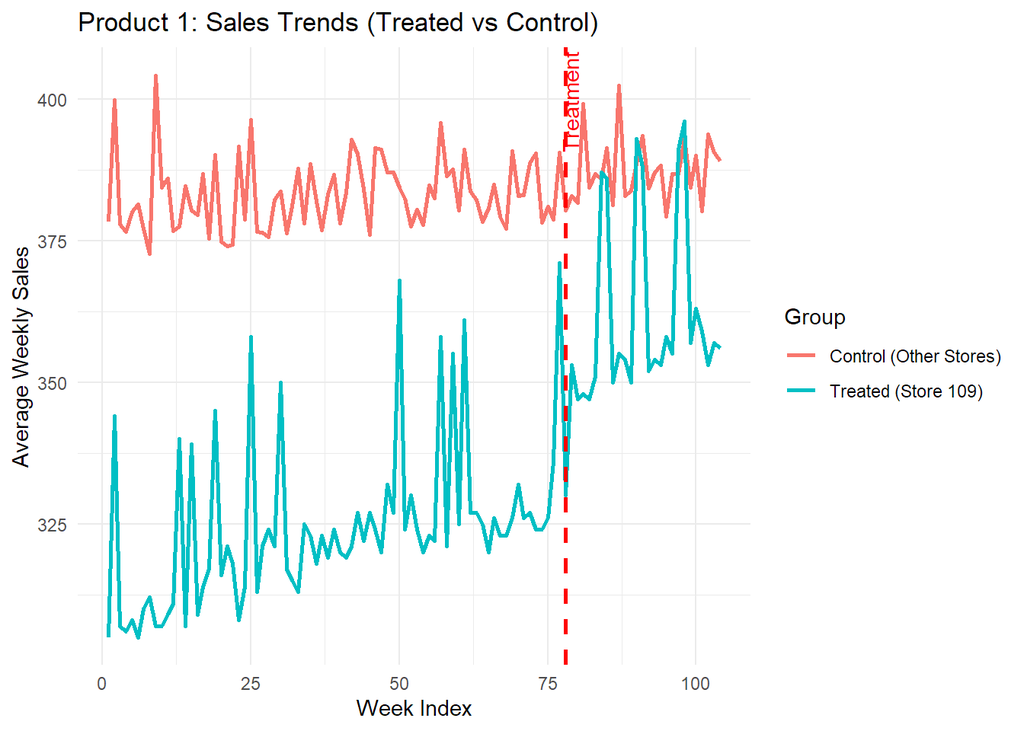

```r
# --- Product 1 Plot ---
# Aggregate average sales per week for treated vs control stores
trend_data_p1 <- df %>%
  group_by(Weekind, is_treated_store) %>%
  summarise(mean_sales = mean(p1sales, na.rm = TRUE), .groups = 'drop') %>%
  mutate(Group = ifelse(is_treated_store == 1, "Treated (Store 109)", "Control (Other Stores)"))

plot_p1 <- ggplot(trend_data_p1, aes(x = Weekind, y = mean_sales, color = Group)) +
  geom_line(linewidth = 1) +
  geom_vline(xintercept = 78, linetype = "dashed", color = "red", linewidth = 1) +
  annotate("text", x = 76, y = max(trend_data_p1$mean_sales),
           label = "Treatment Start", angle = 90, vjust = 1.5, color = "red") +
  labs(title = "Product 1: Sales Trends (Treated vs Control)",
       x = "Week Index",
       y = "Average Weekly Sales") +
  theme_minimal()

print(plot_p1)
```

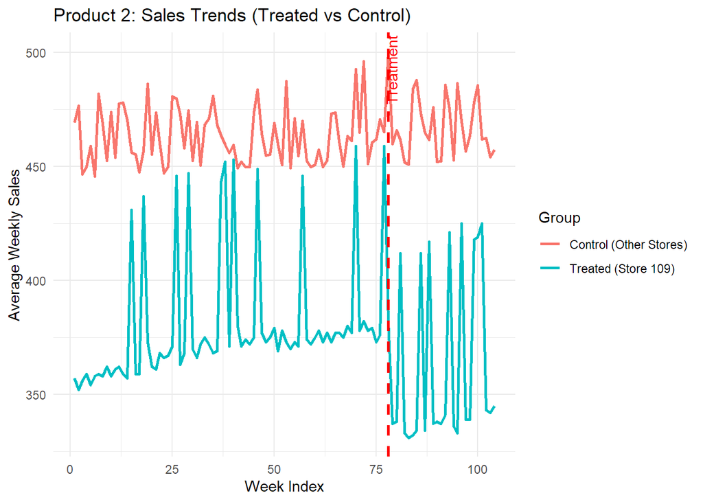

```r
# --- Product 2 Plot ---
trend_data_p2 <- df %>%
  group_by(Weekind, is_treated_store) %>%
  summarise(mean_sales = mean(p2sales, na.rm = TRUE), .groups = 'drop') %>%
  mutate(Group = ifelse(is_treated_store == 1, "Treated (Store 109)", "Control (Other Stores)"))

plot_p2 <- ggplot(trend_data_p2, aes(x = Weekind, y = mean_sales, color = Group)) +
  geom_line(linewidth = 1) +
  geom_vline(xintercept = 78, linetype = "dashed", color = "red", linewidth = 1) +
  annotate("text", x = 76, y = max(trend_data_p2$mean_sales),
           label = "Treatment Start", angle = 90, vjust = 1.5, color = "red") +
  labs(title = "Product 2: Sales Trends (Treated vs Control)",
       x = "Week Index",
       y = "Average Weekly Sales") +
  theme_minimal()

print(plot_p2)
```

### Statistical test for parallel trends: Pre-treatment interaction model

Additionally to doing the visual inspection, we can also run a formal statistical test for parallel trends by regressing sales on the store dummy, a linear time trend (Weekind), and their interaction, but only using the pre-treatment data (Weeks 1 to 77). If the coefficient on the interaction term is statistically significant, it would suggest that the treated store had a different trend compared to the control stores even before the treatment started, which would violate the parallel trends assumption and potentially bias our DiD and SDID estimates.

```r
# Filter the data to ONLY include the pre-treatment period (Weeks 1 to 77)
df_pre <- df %>% filter(Weekind < 78)

# --- Product 1: Parallel Trends Test ---
pt_test_p1 <- lm(p1sales ~ is_treated_store * Weekind, data = df_pre)
summary(pt_test_p1)
```

```
Call:
lm(formula = p1sales ~ is_treated_store * Weekind, data = df_pre)

Residuals:
     Min       1Q   Median       3Q      Max
-169.496  -49.819   -0.924   46.066  168.571

Coefficients:
                          Estimate Std. Error t value Pr(>|t|)
(Intercept)              381.56235    3.47935 109.665  < 2e-16 ***
is_treated_store         -68.18266   15.94439  -4.276 2.01e-05 ***
Weekind                    0.03809    0.07751   0.491    0.623
is_treated_store:Weekind   0.24354    0.35520   0.686    0.493
---
Signif. codes:  0 '***' 0.001 '**' 0.01 '*' 0.05 '.' 0.1 ' ' 1

Residual standard error: 67.61 on 1613 degrees of freedom
Multiple R-squared:  0.03364,   Adjusted R-squared:  0.03185
F-statistic: 18.72 on 3 and 1613 DF,  p-value: 6.166e-12
```

```r
# --- Product 2: Parallel Trends Test ---
pt_test_p2 <- lm(p2sales ~ is_treated_store * Weekind, data = df_pre)
summary(pt_test_p2)
```

```
Call:
lm(formula = p2sales ~ is_treated_store * Weekind, data = df_pre)

Residuals:
    Min      1Q  Median      3Q     Max
-243.39  -71.42   -8.20   76.70  333.94

Coefficients:
                           Estimate Std. Error t value Pr(>|t|)
(Intercept)              462.922368   5.666993  81.687  < 2e-16 ***
is_treated_store         -96.208766  25.969426  -3.705 0.000219 ***
Weekind                    0.006553   0.126245   0.052 0.958611
is_treated_store:Weekind   0.346778   0.578529   0.599 0.548981
---
Signif. codes:  0 '***' 0.001 '**' 0.01 '*' 0.05 '.' 0.1 ' ' 1

Residual standard error: 110.1 on 1613 degrees of freedom
Multiple R-squared:  0.02523,   Adjusted R-squared:  0.02341
F-statistic: 13.91 on 3 and 1613 DF,  p-value: 5.857e-09
```

**Findings:** For both products, the visual interpretation leads to believe that there is a slight positive trend in the treated store’s sales compared to the control stores in the pre-treatment period, which could potentially violate the parallel trends assumption. However, the formal statistical test for parallel trends (the interaction term between the treated store dummy and the linear time trend [is_treated_store:Weekind]) is not statistically significant for either product (p > 0.05). This suggests that while there may be some visual differences in trends, they are not statistically significant enough to conclusively reject the parallel trends assumption possibly due to limited sample size or high variability. Therefore, we can proceed with our DiD and SDID analyses, but we should be cautious in interpreting the results given the potential for some underlying differences in pre-treatment trends.

## Evaluating the treatment effect using DiD, SC, and SDID methods for each product

### Product 1: p1sales

```r
# Ensure data frame is standard class (synthdid prefers plain data.frames over tibbles)
df <- as.data.frame(df)

# Setup panel matrices for Product 1
setup_p1 <- panel.matrices(
  df,
  unit = "storeNum",
  time = "Weekind",
  outcome = "p1sales",
  treatment = "treated"
)

# Estimate the treatment effects for Product 1
sdid_est_p1 <- synthdid_estimate(setup_p1$Y, setup_p1$N0, setup_p1$T0)
did_est_p1 <- did_estimate(setup_p1$Y, setup_p1$N0, setup_p1$T0)
sc_est_p1 <- sc_estimate(setup_p1$Y, setup_p1$N0, setup_p1$T0)
estimates_p1 = list(did_est_p1, sc_est_p1, sdid_est_p1)

# Print the estimates
names(estimates_p1) = c('Diff-in-Diff', 'Synthetic Control', 'Synthetic Diff-in-Diff')
print(unlist(estimates_p1))
```

```
          Diff-in-Diff      Synthetic Control Synthetic Diff-in-Diff
              32.21775               36.37194               14.88871
```

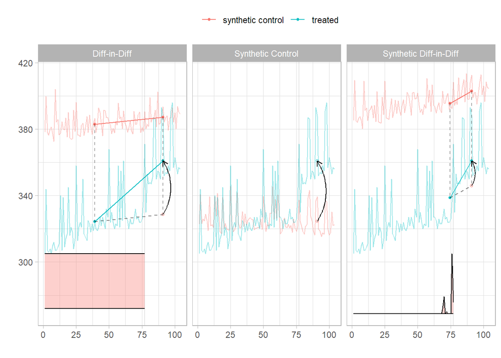

```r
# Plot 1: Trends of treated vs. synthetic control
synthdid_plot(estimates_p1, facet.vertical = FALSE)
```

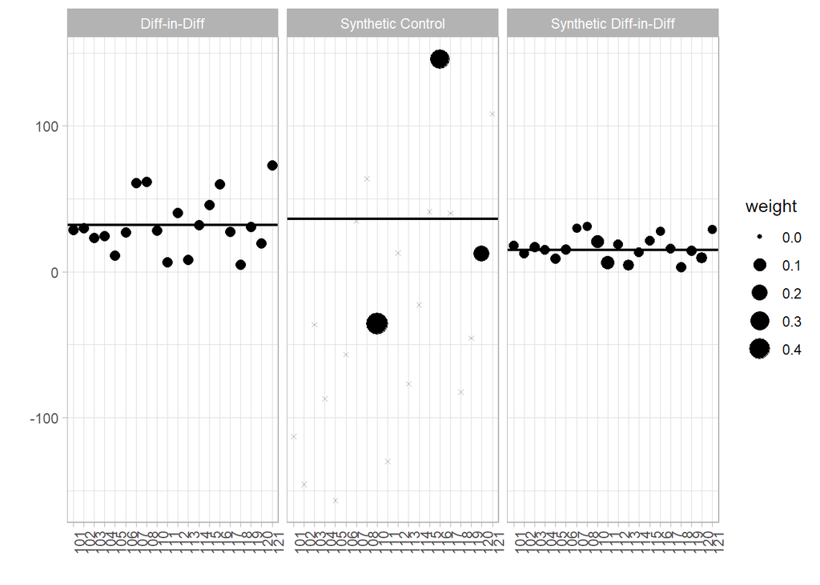

```r
# Plot 2: See which control stores received the highest weights
synthdid_units_plot(estimates_p1)
```

### Product 2: p2sales

The same steps as for Product 1 are repeated for Product 2.

```r
# Setup panel matrices for Product 2
setup_p2 <- panel.matrices(
  df,
  unit = "storeNum",
  time = "Weekind",
  outcome = "p2sales",
  treatment = "treated"
)

# Estimate the treatment effects for Product 2
sdid_est_p2 <- synthdid_estimate(setup_p2$Y, setup_p2$N0, setup_p2$T0)
did_est_p2 <- did_estimate(setup_p2$Y, setup_p2$N0, setup_p2$T0)
sc_est_p2 <- sc_estimate(setup_p2$Y, setup_p2$N0, setup_p2$T0)
estimates_p2 = list(did_est_p2, sc_est_p2, sdid_est_p2)

# Print the estimates
names(estimates_p2) = c('Diff-in-Diff', 'Synthetic Control', 'Synthetic Diff-in-Diff')
print(unlist(estimates_p2))
```

```
          Diff-in-Diff      Synthetic Control Synthetic Diff-in-Diff
             -22.25818              -25.97635              -42.64470
```

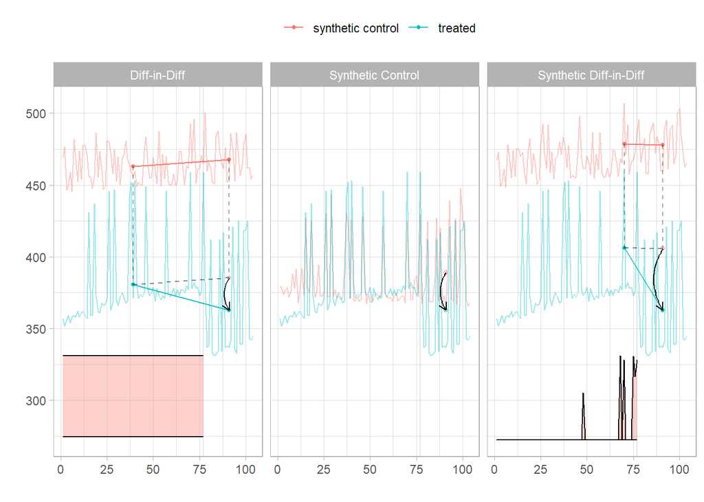

```r
# Plot 1: Trends of treated vs. synthetic control
synthdid_plot(estimates_p2, facet.vertical = FALSE)
```

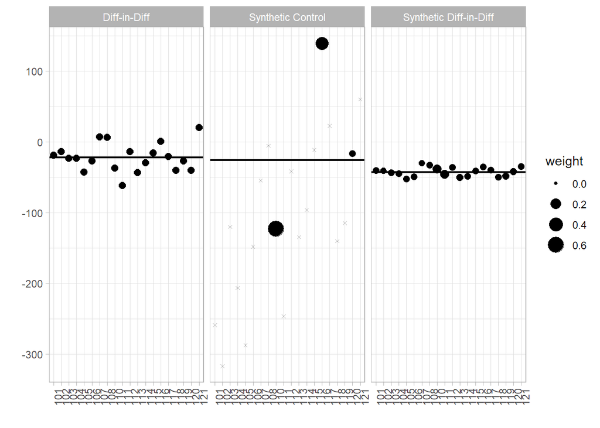

```r
# Plot 2: See which control stores received the highest weights
synthdid_units_plot(estimates_p2)
```

# Expensions to the analysis

Two possible expansions to the analysis include:

1. Running a panel regression-based difference-in-differences model that includes relevant covariates for “pooling”. This implies that it treats the entire dataset as a single pool of observations and uses Ordinary Least Squares (OLS) to estimate the coefficients for dummy veriables to handle store-level and time-period variation.
2. Implementing a version of the SDID method that first regresses out the effects of price and promotions (using the Frisch-Waugh-Lovell theorem) before applying the SDID estimator to the residuals. This will allow us to see how controlling for these covariates in a more flexible way (without assuming linearity or additivity) affects the estimates and their precision.

## Panel regression difference-in-differences

To further explore the data, we can also run a panel regression with a difference-in-differences specification that includes the relevant covariates. This will allow us to compare the results from this more traditional econometric approach with the estimates obtained from the SDID method.

### Product 1: Panel DiD WITH Covariates

```r
did_cov_p1 <- plm(p1sales ~ is_treated_store + post_treatment + treated +
                            p1price + p1prom + compind + storesize + citysize,
                  data = pdf,
                  model = "pooling")
summary(did_cov_p1)
```

```
Pooling Model

Call:
plm(formula = p1sales ~ is_treated_store + post_treatment + treated +
    p1price + p1prom + compind + storesize + citysize, data = pdf,
    model = "pooling")

Balanced Panel: n = 21, T = 104, N = 2184

Residuals:
     Min.   1st Qu.    Median   3rd Qu.      Max.
-50.36165  -5.27904   0.36831   5.32015  44.24457

Coefficients:
                    Estimate  Std. Error  t-value  Pr(>|t|)
(Intercept)       2.0488e+02  2.1580e+00  94.9419 < 2.2e-16 ***
is_treated_store -3.3633e+01  1.3414e+00 -25.0730 < 2.2e-16 ***
post_treatment    3.5381e+00  5.5270e-01   6.4015 1.879e-10 ***
treated           2.9974e+01  2.5287e+00  11.8535 < 2.2e-16 ***
p1price          -2.5853e+00  7.7822e-01  -3.3220 0.0009085 ***
p1prom            3.7619e+01  5.9851e-01  62.8544 < 2.2e-16 ***
compind           9.3823e+01  6.8649e-01 136.6696 < 2.2e-16 ***
storesize         1.2244e+00  7.8548e-03 155.8758 < 2.2e-16 ***
citysize          1.0299e-04  1.0029e-06 102.7016 < 2.2e-16 ***
---
Signif. codes:  0 '***' 0.001 '**' 0.01 '*' 0.05 '.' 0.1 ' ' 1

Total Sum of Squares:    11379000
Residual Sum of Squares: 264690
R-Squared:      0.97674
Adj. R-Squared: 0.97665
F-statistic: 11416 on 8 and 2175 DF, p-value: < 2.22e-16
```

```r
# Product 1: Covariate DiD with Clustered Standard Errors
coeftest(did_cov_p1, vcov = vcovHC(did_cov_p1, type = "HC1", cluster = "group"))
```

```
t test of coefficients:

                    Estimate  Std. Error  t value  Pr(>|t|)
(Intercept)       2.0488e+02  2.5912e+00  79.0685 < 2.2e-16 ***
is_treated_store -3.3633e+01  1.0830e+00 -31.0553 < 2.2e-16 ***
post_treatment    3.5381e+00  3.9689e+00   0.8915 0.3727792
treated           2.9974e+01  4.0396e+00   7.4198 1.672e-13 ***
p1price          -2.5853e+00  7.8067e-01  -3.3116 0.0009428 ***
p1prom            3.7619e+01  1.4219e+00  26.4564 < 2.2e-16 ***
compind           9.3823e+01  3.3419e-01 280.7499 < 2.2e-16 ***
storesize         1.2244e+00  2.0424e-03 599.4855 < 2.2e-16 ***
citysize          1.0299e-04  2.7410e-07 375.7586 < 2.2e-16 ***
---
Signif. codes:  0 '***' 0.001 '**' 0.01 '*' 0.05 '.' 0.1 ' ' 1
```

### Product 2: Panel DiD WITH Covariates

```r
did_cov_p2 <- plm(p2sales ~ is_treated_store + post_treatment + treated +
                            p2price + p2prom + compind + storesize + citysize,
                  data = pdf,
                  model = "pooling")
summary(did_cov_p2)
```

```
Pooling Model

Call:
plm(formula = p2sales ~ is_treated_store + post_treatment + treated +
    p2price + p2prom + compind + storesize + citysize, data = pdf,
    model = "pooling")

Balanced Panel: n = 21, T = 104, N = 2184

Residuals:
     Min.   1st Qu.    Median   3rd Qu.      Max.
-67.46766  -6.34606   0.14586   6.03922  53.12151

Coefficients:
                    Estimate  Std. Error t-value  Pr(>|t|)
(Intercept)       1.5259e+02  2.5743e+00  59.276 < 2.2e-16 ***
is_treated_store -1.8371e+01  1.6208e+00 -11.335 < 2.2e-16 ***
post_treatment    2.9050e+00  6.6751e-01   4.352 1.411e-05 ***
treated          -3.4354e+01  3.0600e+00 -11.227 < 2.2e-16 ***
p2price          -2.8813e+00  8.6397e-01  -3.335 0.0008673 ***
p2prom            8.9915e+01  7.7995e-01 115.284 < 2.2e-16 ***
compind           9.4394e+01  8.3034e-01 113.681 < 2.2e-16 ***
storesize         2.0648e+00  9.5007e-03 217.331 < 2.2e-16 ***
citysize          2.0847e-04  1.2128e-06 171.898 < 2.2e-16 ***
---
Signif. codes:  0 '***' 0.001 '**' 0.01 '*' 0.05 '.' 0.1 ' ' 1

Total Sum of Squares:    28441000
Residual Sum of Squares: 387230
R-Squared:      0.98638
Adj. R-Squared: 0.98633
F-statistic: 19696.6 on 8 and 2175 DF, p-value: < 2.22e-16
```

```r
# Product 2: Covariate DiD with Clustered Standard Errors
coeftest(did_cov_p2, vcov = vcovHC(did_cov_p2, type = "HC1", cluster = "group"))
```

```
t test of coefficients:

                    Estimate  Std. Error  t value  Pr(>|t|)
(Intercept)       1.5259e+02  2.3256e+00  65.6149 < 2.2e-16 ***
is_treated_store -1.8371e+01  1.1091e+00 -16.5636 < 2.2e-16 ***
post_treatment    2.9050e+00  4.0676e+00   0.7142    0.4752
treated          -3.4354e+01  4.4606e+00  -7.7016 2.025e-14 ***
p2price          -2.8813e+00  7.2146e-01  -3.9938 6.719e-05 ***
p2prom            8.9915e+01  4.7046e+00  19.1123 < 2.2e-16 ***
compind           9.4394e+01  1.9037e-01 495.8359 < 2.2e-16 ***
storesize         2.0648e+00  3.7319e-03 553.2849 < 2.2e-16 ***
citysize          2.0847e-04  3.5877e-07 581.0723 < 2.2e-16 ***
---
Signif. codes:  0 '***' 0.001 '**' 0.01 '*' 0.05 '.' 0.1 ' ' 1
```

## Synthetic DiD regressing out the covariates

Given that the base synthdid package used does not easily accept additional control variables (like price and promotions) directly into its primary matrix setup, we can implement a solution based on the Frisch-Waugh-Lovell (FWL) theorem: we first use a linear regression to predict sales based only on the covariates, extract the residuals (the portion of sales unexplained by price, promotions, etc.), and then apply the SDID model to those residuals.

By adding the overall mean back to the residuals, we keep the interpretation on the same scale as the original sales volume.

### Product 1: p1sales

```r
# Run a linear model and extract the residuals (unexplained sales)
model_p1 <- lm(p1sales ~ p1price + p1prom + compind + storesize + citysize, data = df)
df$p1sales_adj <- residuals(model_p1) + mean(df$p1sales, na.rm = TRUE)

# Setup panel matrices using the NEW adjusted outcome variable
setup_p1_adj <- panel.matrices(
  df,
  unit = "storeNum",
  time = "Weekind",
  outcome = "p1sales_adj",
  treatment = "treated"
)

# Estimate the adjusted SDID Treatment Effect
sdid_est_p1_adj <- synthdid_estimate(setup_p1_adj$Y, setup_p1_adj$N0, setup_p1_adj$T0)
print(sdid_est_p1_adj)
```

```
synthdid: 18.519 +- NA. Effective N0/N0 = 14.1/20~0.7. Effective T0/T0 = 1.6/77~0.0. N1,T1 = 1,27.
```

```r
# Calculate and print confidence intervals for Product 1
se_p1_adj <- sqrt(vcov(sdid_est_p1_adj, method = "placebo"))
cat(sprintf("Adjusted 95%% CI: [%.2f, %.2f]\n\n",
            sdid_est_p1_adj - 1.96 * se_p1_adj,
            sdid_est_p1_adj + 1.96 * se_p1_adj))
```

```
Adjusted 95% CI: [11.59, 25.45]
```

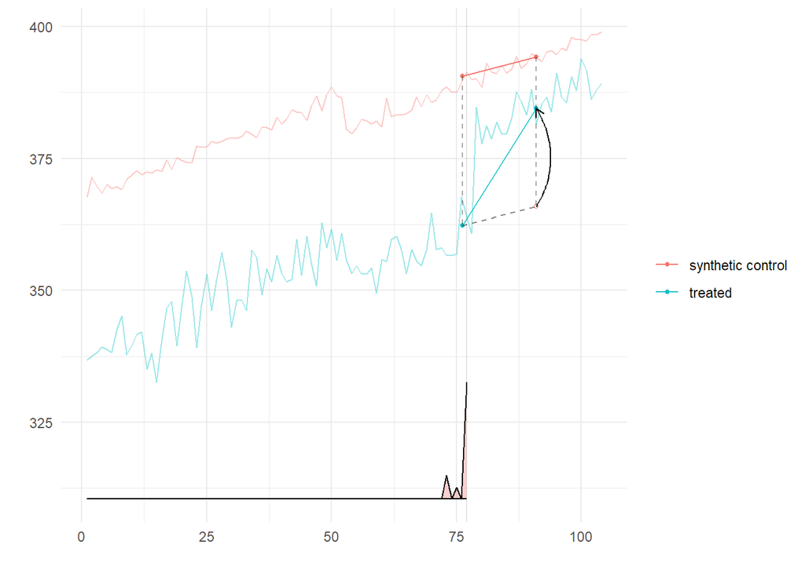

```r
# Visualize adjusted trends
plot(sdid_est_p1_adj)+theme_minimal()
```

### Product 2: p2sales

```r
# Run a linear model and extract the residuals (unexplained sales)
model_p2 <- lm(p2sales ~ p2price + p2prom + compind + storesize + citysize, data = df)
df$p2sales_adj <- residuals(model_p2) + mean(df$p2sales, na.rm = TRUE)

# Setup panel matrices using the NEW adjusted outcome variable
setup_p2_adj <- panel.matrices(
  df,
  unit = "storeNum",
  time = "Weekind",
  outcome = "p2sales_adj",
  treatment = "treated"
)

# Estimate the adjusted SDID Treatment Effect
sdid_est_p2_adj <- synthdid_estimate(setup_p2_adj$Y, setup_p2_adj$N0, setup_p2_adj$T0)
print(sdid_est_p2_adj)
```

```
synthdid: -42.649 +- NA. Effective N0/N0 = 16.2/20~0.8. Effective T0/T0 = 4.2/77~0.1. N1,T1 = 1,27.
```

```r
# Calculate and print confidence intervals for Product 2
se_p2_adj <- sqrt(vcov(sdid_est_p2_adj, method = "placebo"))
cat(sprintf("Adjusted 95%% CI: [%.2f, %.2f]\n\n",
            sdid_est_p2_adj - 1.96 * se_p2_adj,
            sdid_est_p2_adj + 1.96 * se_p2_adj))
```

```
Adjusted 95% CI: [-56.60, -28.70]
```

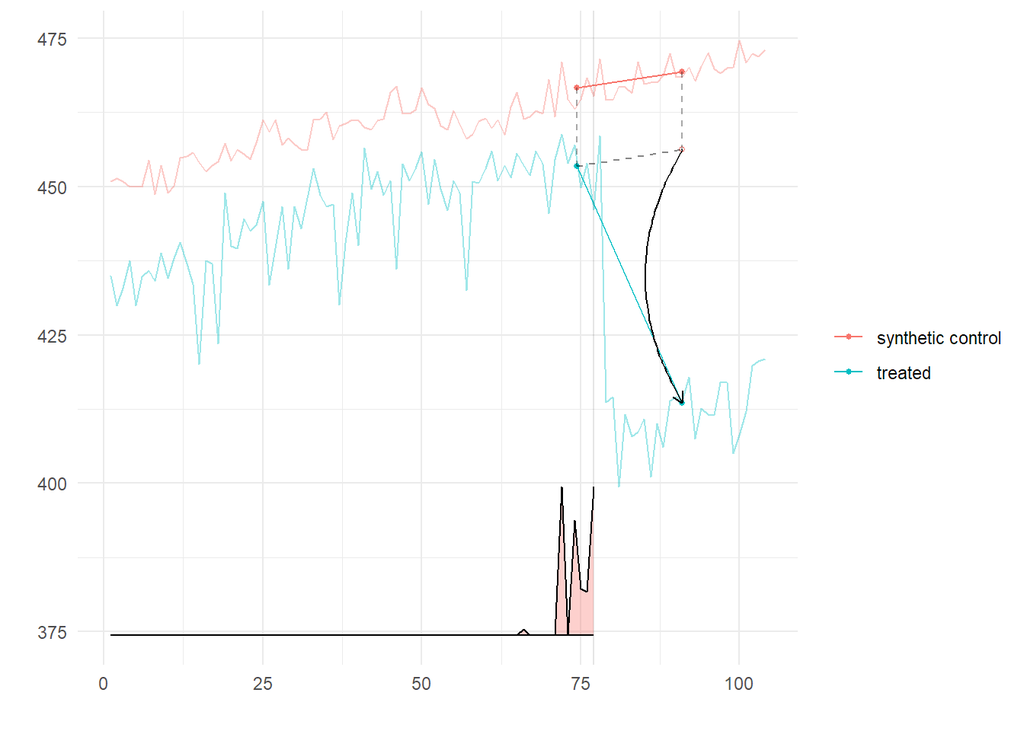

```r
# Visualize adjusted trends
plot(sdid_est_p2_adj)+theme_minimal()
```

# Summary of Findings

Comparison of Treatment Effect Estimates for Product 1 and Product 2

[output not shown]

## Conclusions

### Pre-Post Analysis

In the Pre-Post analysis of Store 109, the pre-post model yielded the following estimates:

- **Product 1:** A significant increase of approximately 33.69 units $(p<0.001)$
- **Product 2:** A significant decrease of approximately 29.71 units $(p<0.001)$

While these numbers provide a clear description of the sales change at Store 109, they are only “appropriate” causal estimates if no other external factors influenced sales between the pre- and post-treatment weeks. If, for example, a competitor ran a major promotion on Product 2 during the same week as the treatment, the pre-post model would wrongly conclude that the in-store marketing caused the sales drop. Therefore, while useful for initial descriptive analysis, more advanced methods like the Two-Way Fixed Effect (TWFE) model or Synthetic Control are generally more appropriate for establishing causality in this dataset as they account for time-varying aggregate shocks.

### Two-Way Fixed Effects (TWFE) Analysis

In the Two-Way Fixed Effects analysis of Store 109, the TWFE model provided more nuanced estimates compared to the naive Pre-Post model:

- **Product 1:** The TWFE estimate was 29.98 units (SE: 4.03), slightly lower and more conservative than the Pre-Post estimate of 33.69
- **Product 2:** The TWFE estimate was -34.29 units (SE: 4.45), showing a more pronounced decrease than the Pre-Post estimate of -29.71

These differences highlight that the TWFE model is more appropriate than the Pre-Post model because it adjusts for weekly sales fluctuations across the entire retail chain, preventing those general trends from being incorrectly attributed to the specific in-store marketing treatment.

### Difference-in-Differences (DID) Analysis

Notably, the standard errors for the simple DID in this specific task were significantly larger than those of the Two-Way Fixed Effects (TWFE) or Adjusted SDID models. This suggests that while a simple DID is a theoretical improvement over a pre-post model, it may lack precision in datasets with high variance between stores unless more granular controls (like fixed effects or matching) are incorporated. While these additions could possibly reduce the standard errors, by looking at the graph, we can see that the data does not follow the parallel trends assumption very well, which is likely contributing to the large standard errors. Therefore, while the simple DID is a step in the right direction for causal inference, it may not be the most appropriate method for this dataset without further adjustments.

### Panel DiD with Covariates Analysis

In the Panel DiD with Covariates analysis of Store 109, the model provided the following estimates:

- **Product 1:** Estimate of 29.97 units (SE: 4.04)
- **Product 2:** Estimate of -34.35 units (SE: 4.46)

The estimates for Product 1 (29.98 vs 29.97) and Product 2 (-34.29 vs -34.35) are almost identical to the TWFE model’s estimates. This indicates that the explicit covariates included in the Panel DID model successfully captured nearly all the systematic store-level differences that the TWFE model’s fixed effects would have absorbed. Also like the TWFE model, the Panel DiD with Covariates model shows very high precision (SEs ~4.0) compared to a Simple DID (SEs ~20.0). This is posibly because both models include prices and promotions as covariates, which tend to have noticeable impact on sales volume. By explaining this variance, both models significantly reduce the noise in the residuals. With that said, the Simple TWFE model is generally considered more robust because it controls for all store characteristics, even those that are not seen or measured. If there were an unobserved store difference not captured by *citysize* or *storesize*, the pooling model could be biased. However, the near-identical results suggest that these covariates were comprehensive for this specific task.

### Synthetic Control (SC) Analysis

While SC provided the highest positive estimate for Product 1, its standard errors in this specific task were notably larger than those of more advanced hybrid methods like Synthetic DID (SDID) or Two-Way Fixed Effects (TWFE). This also aligns with the visual inspection of the trends, where the synthetic control had a reasonable pre-treatment fit but due to the high amount of noise in the data, the post-treatment estimate is less precise and potentially overfitted. This suggests that while SC is appropriate for defining the counterfactual based on pre-treatment trends, its precision can be lower in retail panels unless combined with additional regularization or time-weighting (as seen in SDID).

### Synthetic Difference-in-Differences (SDID) and Adjusted SDID Analysis

**Conservatism vs. Magnitude:** For Product 1, the SDID estimate (18.52) was significantly more conservative than the naive Pre-Post (33.69) or simple DID (32.22) models. This suggests that earlier models were likely overestimating the marketing effect by failing to account for specific control units that shared Store 109’s unique sales trajectory.

**Reliability:** For Product 2, the SDID estimate (-42.65) showed a much stronger negative impact than the simple DID (-22.26). This indicates that when control units are reweighted to match the treated store’s specific behavior, the sales drop appears even more severe.

**Final considerations:** The SDID approach, especially when adjusted for covariates, appears to provide the most reliable and precise estimates of the treatment effect in this retail panel context. It effectively combines the strengths of both SC (defining a data-driven counterfactual) and DID (leveraging time variation), while also controlling for confounding factors through regression adjustment. However it is very important to consider: because SDID often weights only a few time periods directly before the treatment, the estimate can be sensitive to noise in those specific weeks; to prevent over-reliance on a single control unit and ensure a unique solution, SDID uses a regularization constant (ξ) to disperse unit weights; similar to SC, the credibility of SDID rests on the quality of the pre-treatment fit; if the weighted controls cannot reasonably mimic the treated unit’s trend, the resulting estimate may be biased. With those considerations in mind, the SDID method, particularly when adjusted for covariates, appears to be the most appropriate and reliable method for estimating the causal effect of the in-store marketing strategy on sales in this dataset.

## Final decision:

### Recommendations to Management

The primary recommendation is to proceed with caution regarding a full-scale rollout of this marketing strategy. While the strategy successfully drives sales for Product 1, it appears to have a significant negative impact on Product 2 sales. Management should investigate whether this represents a “cannibalization” effect or if the marketing for Product 1 is actively deterring Product 2 purchases. Before a chain-wide implementation, it is essential to calculate the net profit margin of these changes, as the volume loss in Product 2 (~42 units) is more than double the volume gain in Product 1 (~18 units)

### Potential Challenges in the Data

Several characteristics of the retail dataset pose challenges to established causal inference:

- **Violation of Parallel Trends:** Visual inspection and the high standard errors in the simple DID model (~20.0) suggest that Store 109 did not follow the same pre-treatment trajectory as the average of the control stores. Relying on simple models would therefore lead to biased estimates.
- **Independent Price Setting:** Because store managers set prices independently at each store, price becomes an endogenous factor that varies over both time and units. If these price changes coincide with the marketing treatment, they can confound the results.
- **Selection Bias:** The treatment was not randomized; Store 109 was specifically chosen. This introduces “selection on unobservables,” where unique characteristics of that store (e.g., local management culture) might make it more or less responsive to marketing than other stores.